# Phenotypic Profiling

```python
import os
import numpy as np
import matplotlib.pyplot as plt
import pandas as pd
import seaborn.apionly as sns
from src.vis_utils import FeaturePlotter
from IPython.display import Image, set_matplotlib_formats
set_matplotlib_formats('pdf', 'svg')
```

In Ljosa et al. (2013), five approaches to cell population profiling are compared in predicting the mechanism of action (MOA) of known samples. Each approach took a matrix of several hundred extracted features for each cell over each drug treatment in an assay and condensed it in some way (such as by taking the mean, the decision boundary norm of a linear SVM, etc.) and compared it to the same characterisation of a set of annotated profiles. A prediction of MOA was made for the unlabelled profile using the nearest neighbour (1-NN) under the cosine distance, $d(u, v ) = 1 - \cos\theta_{u, v}$. We aim at using classification results in order to build biologically meaningful profiles. The strategy is thus to classify each cell into one out of several meaningful biological classes and to represent each drug perturbation by the percentages of cells in each of the phenotypic categories. This would allow us then to predict the MOA from this profile vector.

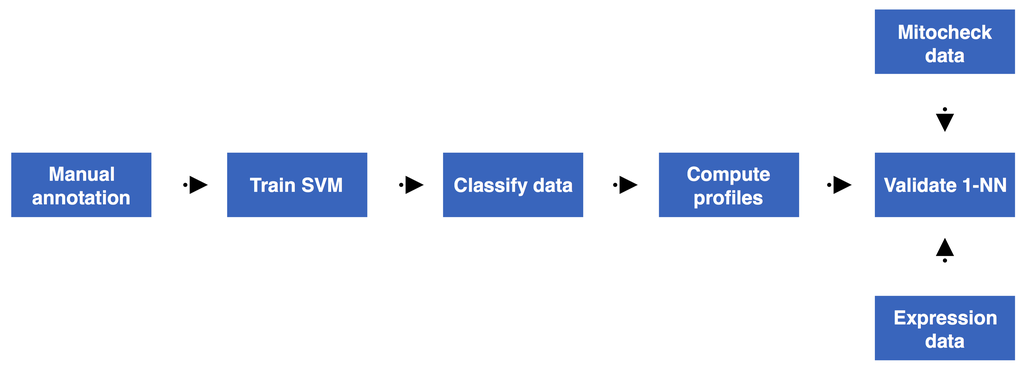

```python
Image('img/profile_flowchart.png')
```

We denote our phenotypic profile as $\mathbf{p} \in \mathbb{R}^K$ for $K$ phenotype classes. Observe that the manually defined phenotype ontology acts as a latent variable behind the distribution of features. When it comes to the straightforward approach of phenotype characterisation in Adams et al. (2004), the phenotype profile $\mathbf{p}' \in \mathbb{R}^D$ for $D$ features is given as $\mathbf{p}' = \frac{1}{N}\sum_{n=1}^{N}\mathbf{x}_n$ for the $N$ observations in the data set. Yet, under the hypothesis of a latent phenotype variable, $$\mathbf{p}' \to \sum_{k=1}^Kp_k\mathbf{f}_k$$ as $N \to \infty$, where the $p_k$ are the proportions of each of the $K$ phenotypes as measured by our approach, and the $\mathbf{f}_k$ are the average feature vector for each phenotype--the archetypal phenotypes, as it were. As such, $\mathbf{p}' \to \mathbf{F}\mathbf{p}$ as $N \to \infty$, with $\mathbf{F} \in \mathbb{R}^{D \times K}$ the matrix of $\mathbf{f}_k$. Thus, the Adams profile is approximately equivalent to our own projected into a high dimensional linear space. It therefore seems unlikely that cosine distances calculated by the former approach will be as meaningful as with our own.

```python
base_folder = '/Users/jcboyd/Documents/12CellLines-morphology/'
plate = '12CellLines-morphology'
ch5_folder = os.path.join(base_folder, 'cecog_out/%s/hdf5/' % plate)
```

|  | Interphase | Longest phase, cell nucleus is typically small and convex |
| --- | --- | --- |
|  | Large interphase | Large interphase nucleus, possible replication defect |
|  | Bright interphase | DAPI at higher intensity, due to cell cycle deregulation |
|  | Prometaphase | Mitotic phase, prior to division (short $\implies$ infrequent) |
|  | Metaphase | Chromosome alignment |
|  | Polylobed | Abnormal shape--mitosis abberation |
|  | Apoptosis | Cell death |

```python
cell_lines = ['MDAMB231', 'MCF10A', 'Hs578T', 'MDAMB157', 'HCC1143', 'HCC38',
              'MDAMB468', 'HCC1937', 'MDAMB436', 'BT20', 'BT549', 'HCC70']

classes = [
    'Normal Interphase',
    'Large',
    'Prometaphase',
    'Metaphase',
    'Apoptosis',
    'Polylobed',
    'Bright Interphase']
```

```python
from src.phenotype_profiling import PhenotypeProfiler

pp = PhenotypeProfiler(ch5_folder, classes, cell_lines)
pp.read_classifications(plate)
```

```
[####################################################################################################] (100%)
```

### Profile Visualisation

```python
"""
Aggregate over well fields
"""
pp.group_fields()
```

```python
fp = FeaturePlotter()
fig, ax = plt.subplots(figsize=(8, 3))
img = fp.plot_cell_profiles(ax, pp.df_morph[classes].as_matrix().T, cell_lines, classes,
                            title='Class frequencies by cell line',
                            cmap='viridis', normalise=True)
plt.colorbar(img, orientation='vertical', fraction=0.05, pad=0.05)
plt.show(fig)
```

[figure not shown]

Note the negative control, MCF10A (non-cancerous cell line)

```python
df_norm = pp.df_morph.copy()

"""
Normalise by subtracting negative control
"""
df_norm[classes] = df_norm[classes].div(df_norm[classes].sum(axis=1), axis=0)
mcf10a_mean = df_norm[df_norm['Cell Line'] == 'MCF10A'][classes].mean(axis=0)
df_norm[classes] = df_norm[classes].subtract(mcf10a_mean)

"""
Combine columns
"""
df_norm['Interphase'] = df_norm['Normal Interphase'] + df_norm['Bright Interphase']
df_norm['Mitosis'] = df_norm['Prometaphase'] + df_norm['Metaphase']
df_norm = df_norm.drop(
    ['Metaphase', 'Prometaphase', 'Normal Interphase', 'Bright Interphase'], axis=1)

"""
Take median of counts from wells
"""
df_medians = df_norm.groupby(by='Cell Line', as_index=False).median()
```

Here we normalise similarly to MitoCheck (Neumann et al., 2010): subtracting the negative control, and take median of the 8 replicates. We combine columns to make them comparable to the MitoCheck data.

### Mitocheck Comparison

```python
mitocheck_classes = [
    'Interphase',
    'Mitosis',
    'Large',
    'Polylobed',
    'Apoptosis']
```

```python
"""
Import MitoCheck data
"""
mitocheck_path = 'data/sirna_scores_export.txt'
df_mitocheck = pd.DataFrame.from_csv(mitocheck_path, sep='\t', index_col=None)
df_mitocheck = df_mitocheck[['ensembl gene'] + mitocheck_classes]
df_mitocheck.head(10)
```

|  | ensembl gene | Interphase | Mitosis | Large | Polylobed | Apoptosis |
| --- | --- | --- | --- | --- | --- | --- |
| 0 | ENSG00000132964 | 0.037949 | 0.003457 | 0.012236 | 0.010413 | 0.011529 |
| 1 | ENSG00000135090 | 0.029031 | 0.008388 | -0.002144 | 0.042463 | 0.015754 |
| 2 | ENSG00000105371 | 0.026479 | 0.003148 | -0.005948 | 0.001495 | 0.013936 |
| 3 | ENSG00000167862 | 0.019523 | 0.006401 | 0.009295 | 0.029081 | 0.014292 |
| 4 | ENSG00000172201 | 0.017809 | 0.015816 | 0.017743 | 0.102247 | 0.006421 |
| 5 | ENSG00000119922 | 0.034117 | 0.004804 | 0.013236 | 0.031584 | 0.022953 |
| 6 | ENSG00000185745 | 0.044440 | 0.005056 | 0.010954 | 0.012699 | 0.008759 |
| 7 | ENSG00000119917 | -0.002473 | 0.007086 | -0.007180 | -0.006980 | 0.036597 |
| 8 | ENSG00000006652 | 0.060159 | 0.005549 | 0.028499 | 0.016852 | 0.072129 |
| 9 | ENSG00000141753 | -0.005462 | 0.008497 | 0.001841 | 0.022146 | 0.002882 |

```python
"""
Find top k for each cell line
"""
k = 10
df_pred = pp.predict_top_k(df_medians, df_mitocheck, mitocheck_classes, k)
"""
Display top K results
"""
df_pred[['Cell Line', 'ensembl gene', 'Distance'] + mitocheck_classes].head()
```

|  | Cell Line | ensembl gene | Distance | Interphase | Mitosis | Large | Polylobed | Apoptosis |
| --- | --- | --- | --- | --- | --- | --- | --- | --- |
| 0 | MDAMB231 | ENSG00000101182 | 0.294471 | 0.008058 | -0.000013 | 0.037514 | -0.009426 | 0.016933 |
| 1 | MDAMB231 | ENSG00000184277 | 0.302104 | -0.002835 | -0.000885 | 0.046338 | -0.004261 | 0.008271 |
| 2 | MDAMB231 | ENSG00000172889 | 0.329226 | 0.007719 | -0.000740 | 0.013215 | -0.007012 | 0.009699 |
| 3 | MDAMB231 | ENSG00000127511 | 0.339729 | 0.016377 | 0.000020 | 0.033305 | -0.010599 | 0.002648 |
| 4 | MDAMB231 | ENSG00000109689 | 0.340304 | 0.011958 | -0.000959 | 0.020785 | -0.006985 | -0.000060 |

### Gene expression data

```python
expression_cell_lines = {
    'MDAMB231' : 'MDA-MB-231', 'MCF10A' : 'MCF-10A', 'Hs578T' : 'Hs-578T',
    'MDAMB157' : 'MDA-MB-157', 'HCC1143' : 'HCC-1143', 'HCC38' : 'HCC-38',
    'MDAMB468' : 'MDA-MB-468', 'HCC1937' : 'HCC-1937', 'MDAMB436' : 'MDA-MB-436',
    'BT20' : 'BT-20', 'BT549' : 'BT-549', 'HCC70' : 'HCC-70'}
headers = expression_cell_lines.values()
```

```python
df_exp = pd.read_csv('data/GeneExpressionInBreastCancerCellLines_101213.csv', sep=';')
df_exp.head()[headers]
```

|  | BT-549 | MDA-MB-468 | MCF-10A | HCC-1937 | MDA-MB-157 | MDA-MB-231 | MDA-MB-436 | HCC-38 | HCC-70 | BT-20 | Hs-578T | HCC-1143 |
| --- | --- | --- | --- | --- | --- | --- | --- | --- | --- | --- | --- | --- |
| 0 | 5.491495 | 5.475640 | 5.284930 | 5.40929 | 5.086835 | 5.320125 | 5.303665 | 5.129280 | 5.629285 | 5.283500 | 5.486130 | 5.321475 |
| 1 | 6.266790 | 6.614710 | 6.459430 | 6.61471 | 6.409390 | 6.554590 | 6.794420 | 6.129280 | 6.672430 | 6.491850 | 6.475730 | 6.442940 |
| 2 | 6.483790 | 6.383470 | 6.819955 | 6.48271 | 6.658145 | 6.158985 | 6.670690 | 7.256895 | 6.357550 | 6.725605 | 6.593675 | 7.021980 |
| 3 | 7.514170 | 7.331725 | 7.686500 | 7.57978 | 7.422055 | 7.977280 | 7.654630 | 7.455320 | 7.365900 | 7.813080 | 7.721665 | 7.452740 |
| 4 | 6.857980 | 7.087460 | 7.179910 | 7.05528 | 7.033420 | 6.942510 | 6.807350 | 7.118940 | 7.569860 | 6.930740 | 7.139550 | 7.011230 |

```python
"""
Normalise data
"""
df_exp[headers] = df_exp[headers].subtract(df_exp['MCF-10A'], axis=0).divide(df_exp['MCF-10A'], axis=0)
df_exp[headers] = abs(df_exp[headers])
```

```python
plot_data = {}
k = len(df_mitocheck)
df_pred = pp.predict_top_k(df_medians, df_mitocheck, mitocheck_classes, k)

for cell_line in cell_lines:
    preds = df_pred[df_pred['Cell Line'] == cell_line]['ensembl gene'].get_values()
    exp_cell_line = expression_cell_lines[cell_line]
    exp_ranked = df_exp.sort_values(exp_cell_line)['EnsEMBL ID'].get_values()
    plot_data[cell_line] = pp.get_plot_data(preds, exp_ranked)
```

```python
def multi_plot(vals, ax):
    for i, cell_line in enumerate(vals.keys()):
        ax.plot(vals[cell_line]['x'], vals[cell_line]['y'], color='blue', lw=1)

    ax.set_title('Predictions until non-zero overlap')
    ax.set_xscale('log')
    ax.set_yscale('log')
    ax.set_xlabel('top k predictions')
    ax.set_ylabel('top k expressions')
    ax.grid('on')
```

```python
fig, ax = plt.subplots()
multi_plot(plot_data, ax)
ax.plot(*pp.get_probability_series(n=len(df_mitocheck), tol=0.1), color='red')
plt.show()
```

[figure not shown]

If we randomly choose $g$ gene expression candidates and $r$ RNAi candidates, from the same pool of $n$ genes, the probability of at least one overlap between g and r (resembling the birthday paradox) is given by,

$$p(\# matches \geq 1) = 1 - \frac{n - g}{n} \times \frac{n - g - 1}{n - 1} \times \cdots \times \frac{n - g - r + 1}{n - r + 1} = 1 - \prod_{i=0}^{r-1} \frac{n - g - i}{n - i}$$